# MATH 3070 Lab Project 8

Kanishka Ragula

October 19, 2017

*Remember: I expect to see commentary either in the text, in the code with comments created using `#`, or (preferably) both! **Failing to do so may result in lost points!***

## Problem 1 (Verzani problem 3.2)

*For the `michelson` (**MASS**) data set, produce a density plot comparing `Speed` between Experiments 1 and 2.*

```r
#Library stuffs
library(UsingR)
library(aplpack)
```

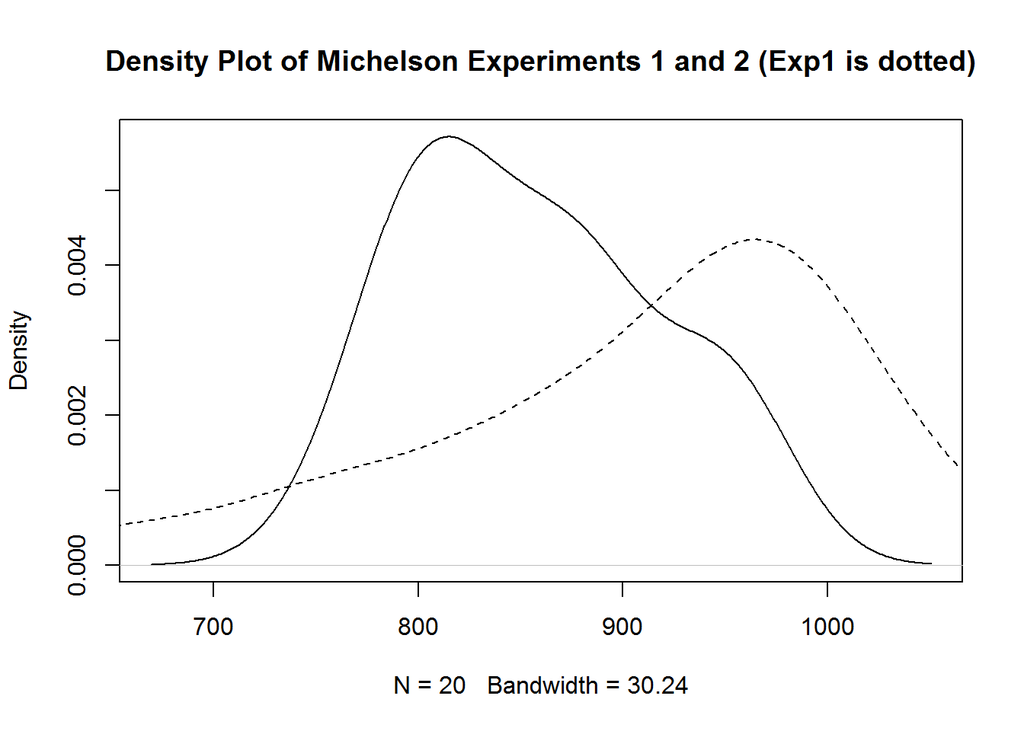

```r
#Split the data by experiment
mich_split = with(michelson, split(Speed, Expt))

#Create vectors for each experiment
exp1 = mich_split$"1"
exp2 = mich_split$"2"

#Plot the data after giving the title
plotOne = plot(density(exp2),main = "Density Plot of Michelson Experiments 1 and 2 (Exp1 is dotted)", lty = 1)
lines(density(exp1), lty = 2)
```

## Problem 2 (Verzani problem 3.4)

*Three students record the time spent on homework per class. Their data is:*

| Student | 1 | 2 | 3 | 4 | 5 |
| --- | --- | --- | --- | --- | --- |
| Marsha | 25 | 0 | 45 | 90 | 0 |
| Bill | 30 | 30 | 30 | 30 |  |
| Holly | 15 | 0 | 90 | 0 |  |

*Use a list to store these values. Then create a boxplot to compare. (You must use `boxplot()`’s formula interface for this problem.)*

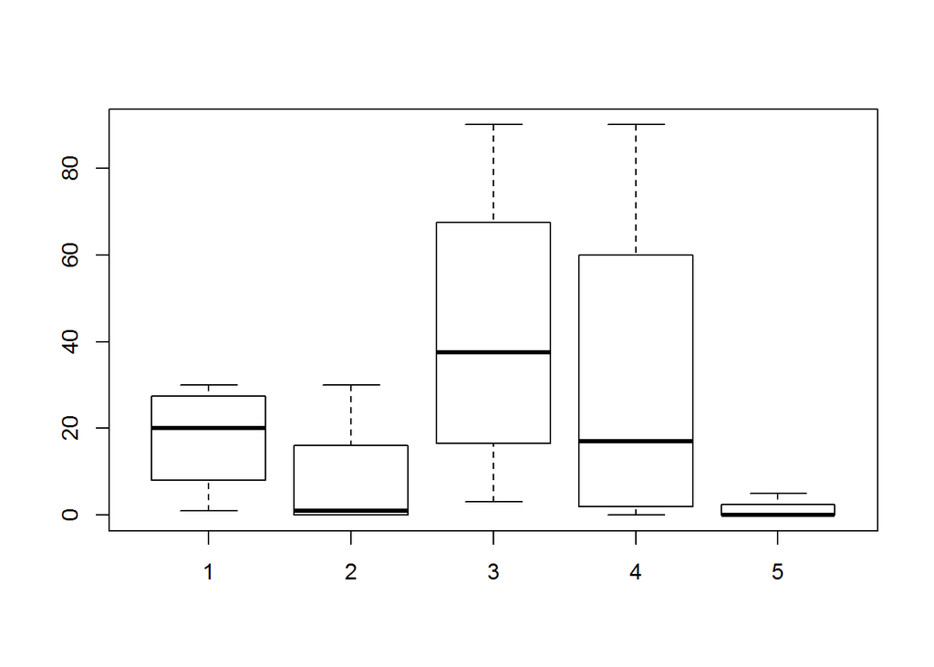

```r
library(Hmisc)
#Library Stuffs again
#Create the data lists by person and class
Class = c(1,2,3,4,5)
Marsha = c(25, 0, 45, 90, 0)
Bill = c(30,30,30,30, 0)
Holly = c(15, 0, 90,0, 0)

#Create a data frame to store this
y=data.frame(Class, Marsha, Bill, Holly)
boxplot(t(y))
```

```r
#Plot the transpose of the boxplot to compare classes
```

## Problem 3 (Verzani problem 3.5)

*A group of nursing students take turns measuring some basic assessments. Their data is:*

|  | Temp | Pulse | Systolic | Diastolic |
| --- | --- | --- | --- | --- |
| Jackie | 98.2 | 96 | 134 | 90 |
| Florence | 98.6 | 56 | 120 | 80 |
| Mildred | 98.2 | 76 | 150 | 95 |

*Create a data frame of these values. Will `plot()` and `boxplot()` produce the same graphic?*

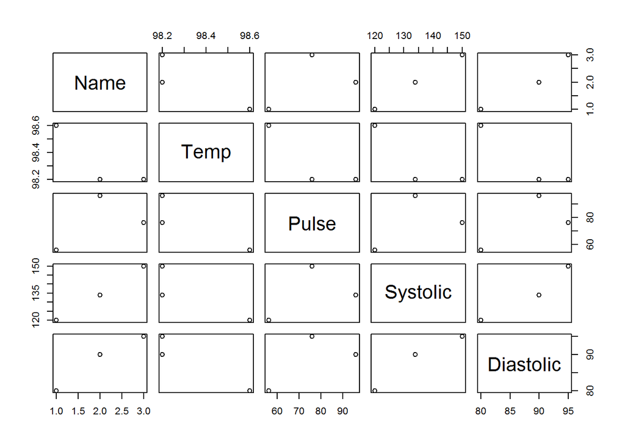

```r
#Create the data vectors for each type of data
Name = c("Jackie", "Florence", "Mildred")
Temp = c(98.2, 98.6, 98.2)
Pulse = c(96,56,76)
Systolic = c(134, 120, 150)
Diastolic = c(90,80,95)

#Create the data frame
x = data.frame(Name, Temp, Pulse, Systolic, Diastolic)
#Plot the data
plot(x)
```

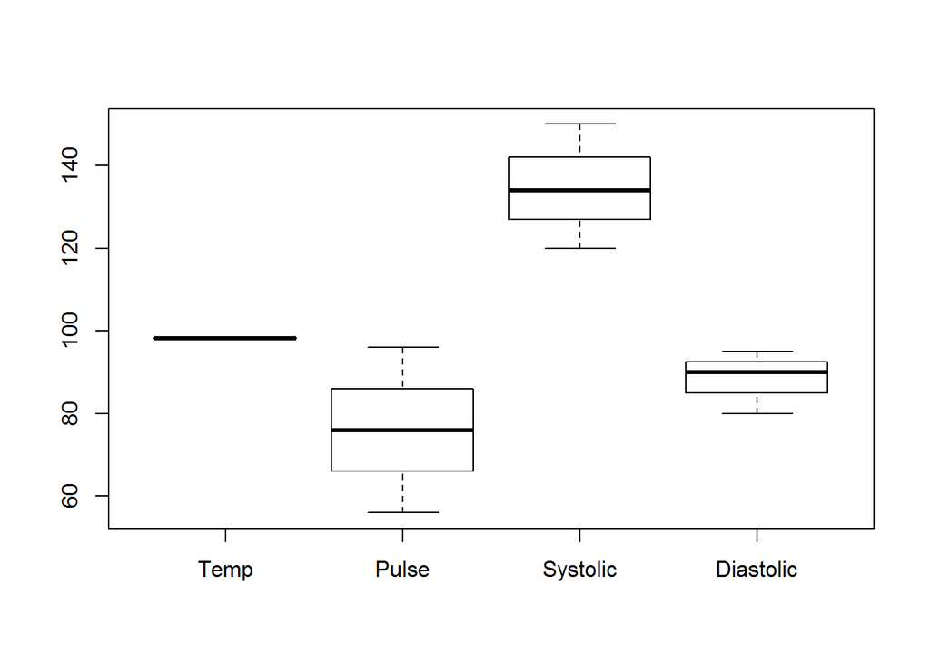

```r
boxplot(x[2:5])
```

```r
#These give different results
```

## Problem 4 (Verzani problem 3.8)

*The second argument to `split` can be a list of factors. The result is that all interactions (possible combinations) are used for the groups. In the `ToothGrowth` data set, growth (`len`) is measured for two types of supplements (`supp`) and three doses (`dose`). Split this `len` value into 6 groups.*

```r
split(ToothGrowth$len, paste(ToothGrowth$supp, ToothGrowth$dose)) #Breaks len by the Supplement and Dose
```

```
## $`OJ 0.5`
##  [1] 15.2 21.5 17.6  9.7 14.5 10.0  8.2  9.4 16.5  9.7
##
## $`OJ 1`
##  [1] 19.7 23.3 23.6 26.4 20.0 25.2 25.8 21.2 14.5 27.3
##
## $`OJ 2`
##  [1] 25.5 26.4 22.4 24.5 24.8 30.9 26.4 27.3 29.4 23.0
##
## $`VC 0.5`
##  [1]  4.2 11.5  7.3  5.8  6.4 10.0 11.2 11.2  5.2  7.0
##
## $`VC 1`
##  [1] 16.5 16.5 15.2 17.3 22.5 17.3 13.6 14.5 18.8 15.5
##
## $`VC 2`
##  [1] 23.6 18.5 33.9 25.5 26.4 32.5 26.7 21.5 23.3 29.5
```